# cluster

## Clustering Mandatory

In this notebook, we will perform clustering on the red and white wine datasets. We will use both KMeans and Agglomerative Clustering methods to group the data points based on their features. We will also evaluate the clustering performance using internal metrics such as silhouette score and Davies-Bouldin index. I've also added several metrics in which I per today don't have a good understanding of, but I've included them for completeness and for future competence development.

### Package imports

#### Packages I understand

- numpy - Numerical operations
- pandas - Data manipulation and analysis
- matplotlib - Data visualization
- seaborn - Statistical data visualization
- sklearn
  - cluster - Clustering algorithms
  - metrics
    - silhouette_score - Haven't grasped the calculations yet, but I understand it's a measure of how similar an object is to its own cluster compared to other clusters. Whereas the target is to have a high value, close to 1.
    - davies_bouldin_score - The score is defined as the average similarity measure of each cluster with its most similar cluster, where similarity is the ratio of within-cluster distances to between-cluster distances. Thus, clusters which are farther apart and less dispersed will result in a better score. The minimum score is zero, with lower values indicating better clustering.
  - pipeline - To create a pipeline of transforms with a final estimator
- imblearn - For handling imbalanced datasets
  - SMOTE - Synthetic Minority Over-sampling Technique, used to balance class distribution.

#### Packages I don't fully understand yet, but have included for future competence development

- sklearn
  - metrics
    - adjusted_rand_score - Is a function that measures the similarity between two data clusterings by considering all pairs of samples and counting pairs that are assigned in the same or different clusters in the predicted and true clusterings. The score is adjusted for chance, meaning that random labelings will have an expected score of 0. The maximum score is 1, indicating perfect agreement between the two clusterings.
    - mutual_info_score - Mutual Information (MI) measures the amount of information that one random variable contains about another. In clustering evaluation, it quantifies how much knowing the predicted cluster labels reduces uncertainty about the true labels (and vice versa). A higher MI score indicates a stronger agreement between the clustering and the ground truth.
    - adjusted_mutual_info_score - Adjusted Mutual Information (AMI) is a measure used to evaluate the similarity between two clustering results, adjusting for chance. It quantifies how much information is shared between the predicted clusters and the true labels, with a score ranging from 0 (no agreement) to 1 (perfect agreement). AMI is particularly useful for comparing clustering algorithms, as it accounts for random chance in the clustering assignments.
    - normalized_mutual_info_score - Normalized Mutual Information (NMI) is a measure of the agreement between two clustering results, normalized to account for the size of the clusters. It ranges from 0 (no agreement) to 1 (perfect agreement) and is useful for comparing clusterings with different numbers of clusters.
    - fowlkes_mallows_score - Fowlkes-Mallows Index (FMI) is a measure of the similarity between two clusters by considering the pairs of samples that are assigned to the same or different clusters. It ranges from 0 (no agreement) to 1 (perfect agreement) and is particularly useful for evaluating clustering algorithms.
    - completeness_score - Completeness Score is a measure of how well all samples that are assigned to the same cluster are also assigned to the same ground truth cluster. It ranges from 0 (no completeness) to 1 (perfect completeness) and is useful for evaluating clustering algorithms.
    - v_measure_score - V-Measure is a measure of the balance between homogeneity and completeness in a clustering result. It ranges from 0 (no agreement) to 1 (perfect agreement) and is useful for evaluating clustering algorithms.
    - homogeneity_completeness_v_measure - Homogeneity, Completeness, V-Measure is a combined measure that takes into account homogeneity, completeness, and V-Measure in a single score. It ranges from 0 (no agreement) to 1 (perfect agreement) and is useful for evaluating clustering algorithms.
  - preprocessing
    - MinMaxScaler - A technique used to scale features to a fixed range, usually 0 to 1. It transforms the data by subtracting the minimum value and dividing by the range (max - min). This is useful for algorithms that are sensitive to the scale of the data.
    - StandardScaler - A technique used to standardize features by removing the mean and scaling to unit variance. It transforms the data to have a mean of 0 and a standard deviation of 1. This is useful for algorithms that assume the data is normally distributed.

```python
import numpy as np
import pandas as pd
import matplotlib.pyplot as plt
import seaborn as sb

from sklearn.decomposition import PCA
from sklearn.cluster import KMeans, AgglomerativeClustering
from sklearn.metrics import (silhouette_samples,
                            silhouette_score,
                            davies_bouldin_score,
                            adjusted_rand_score,
                            rand_score,
                            homogeneity_score,
                            completeness_score,
                            v_measure_score,
                            homogeneity_completeness_v_measure)
from sklearn.pipeline import make_pipeline
from sklearn.preprocessing import StandardScaler
```

### Functions

- evaluate_internal(model, X)  
  Evaluates the clustering model using internal metrics such as silhouette score and Davies-Bouldin index.
- evaluate_external(model, X, y)  
  Evaluates the clustering model using external metrics such as Adjusted Rand Index and Mutual Information.
- inertia_silhouette_score_plot(X, size=11)  
  Plots inertia and silhouette scores for different numbers of clusters to help determine the optimal number of clusters with the elbow method.
- target_bar_compare(df1, df2)  
  Compares the distribution of target classes in two datasets using bar plots.
- corr_matrix_compare(df1, df2)  
  Compares the correlation matrices of two datasets using heatmaps.
- get_df_name(df)  
  Returns the variable name of a given DataFrame.
- silhouette_coefficient_plot(X, levels=2, width=4, size=11):  
  Plots the silhouette coefficients for each sample in the clustering result to visualize how well each sample is clustered.
- run_kmeans(X, y, ks=(2,3,4,5,6), seeds=(0,1,2,3,4,5,6,7,8,9))  
  Runs KMeans clustering for different numbers of clusters and random seeds, and evaluates the results using internal and external metrics.
- run_agglomerative(X, y, ks=(2,3,4,5,6), linkages=('ward','average','complete'))  
  Runs Agglomerative Clustering for different numbers of clusters and linkage methods, and evaluates the results using internal and external metrics.
- pca_scatter(X, labels, title="PCA(2) by clusters")  
  Reduces the data to 2 dimensions using PCA and creates a scatter plot colored by cluster labels.

```python
def evaluate_internal(model, X):
    predictions = model.predict(X)
    silhouette = silhouette_score(X, predictions)
    davies_bouldin = davies_bouldin_score(X, predictions)
    print(f'Silhouette: {silhouette:.4f}')
    print(f'Davies Boulding: {davies_bouldin:.4f}')

def evaluate_external(estimator, X, y, return_pred=False, verbose=True):
    # Get cluster labels
    if hasattr(estimator, "fit_predict"):
        labels = estimator.fit_predict(X)
    else:
        estimator.fit(X)
        labels = estimator.predict(X)

    # External metrics
    ari = adjusted_rand_score(y, labels)
    ri  = rand_score(y, labels)  # For reference
    h, c, v = homogeneity_completeness_v_measure(y, labels)

    if verbose:
        print(f"Adjusted Rand Index (ARI): {ari:.4f}")
        print(f"Rand Index (RI)         : {ri:.4f}")
        print(f"Homogeneity             : {h:.4f}")
        print(f"Completeness            : {c:.4f}")
        print(f"V-measure               : {v:.4f}")

    result = {"ARI": ari, "RI": ri, "homogeneity": h, "completeness": c, "v_measure": v}
    if return_pred:
        return result, labels
    return result

def inertia_silouette_score_plot(X, size=11):
    scores_inertia = []
    scores_silhouette = []
    n_clusters_to_test = range(2,size)
    for n in n_clusters_to_test:
        km = KMeans(n_clusters=n).fit(X)
        scores_inertia.append(km.inertia_)
        scores_silhouette.append(silhouette_score(X, km.predict(X)))
    fig, ax = plt.subplots(1,2, figsize=(10,5))
    ax[0].plot(n_clusters_to_test, scores_inertia, label='Inertia')
    ax[1].plot(n_clusters_to_test, scores_silhouette, label='Silhouette')
    ax[0].legend()
    ax[1].legend()

def target_bar_compare(df1, df2):
    fig, ax = plt.subplots(1,2, figsize=(10,5))
    sb.countplot(x='quality', data=df1, ax=ax[0])
    sb.countplot(x='quality', data=df2, ax=ax[1])
    ax[0].set_title(get_df_name(df1))
    ax[1].set_title(get_df_name(df2))

def corr_matrix_compare(df1, df2):
    numCorr1 = df1.corr()
    numCorr2 = df2.corr()
    fig, ax = plt.subplots(1,2, figsize=(23,7))
    sb.heatmap(numCorr1, annot=True, cmap='coolwarm', ax=ax[0])
    sb.heatmap(numCorr2, annot=True, cmap='coolwarm', ax=ax[1])
    ax[0].set_title(get_df_name(df1))
    ax[1].set_title(get_df_name(df2))

def get_df_name(df):
    name =[x for x in globals() if globals()[x] is df][0]
    return name

def silhouette_coefficient_plot(X, levels=2, width=4, size=11):
    # Create Silhouette Coefficient plot
    fig, ax = plt.subplots(levels, width, sharey=True, figsize=(20,5))
    # Loop through candidates for n_clusters between 2 and size
    n_clusters_to_test = range(2,size)
    for n in n_clusters_to_test:
        # Train KMeans with n_clusters set to n
        km = KMeans(n_clusters=n).fit(X)
        # Make predictions on the training data
        predictions = km.predict(X)
        # Find both the average silhouette score, to be plotted as a dotted line (the same as the right figure above)
        silhouette_average = silhouette_score(X, predictions)
        # Find the silhouette score for each sample
        silhouette_sample = silhouette_samples(X, predictions)
        # The fill_between plotting technique requires that we keep track of where the next
        # cluster will start on the x-axis
        x_start = 0
        # Loop through all the clusters in the range [0,n)
        for i in range(n):
            # Retrieve the samples that are assigned to the current cluster i and sort them
            ith_cluster_samples = silhouette_sample[km.labels_ == i]
            ith_cluster_samples.sort()
            # Find the end of fill_between
            x_end = x_start + ith_cluster_samples.shape[0]
            # access the appropriate ax and draw the silhouette coefficients using fill_between and the average using
            # a regular line plot
            ax[(n-levels)//width][(n-levels)%width].fill_between(np.arange(x_start, x_end), 0, ith_cluster_samples)
            ax[(n-levels)//width][(n-levels)%width].axhline(y=silhouette_average, ls='--', color='black')
            ax[(n-levels)//width][(n-levels)%width].set_title(n)
            # Advance the x position to the start of the next cluster
            x_start = x_end

def run_kmeans(X, y, ks=(2,3,4,5,6), seeds=(0,1,2,3,4,5,6,7,8,9)):
    rows = []
    for k in ks:
        for rs in seeds:
            km = make_pipeline(StandardScaler(), KMeans(n_clusters=k, n_init=20, random_state=rs))
            labels = km.fit_predict(X)
            Xs = km[:-1].transform(X)
            rows.append({
                'algo':'kmeans', 'k':k, 'seed':rs,
                'silhouette': silhouette_score(Xs, labels),
                'dbi': davies_bouldin_score(Xs, labels),
                'ari': adjusted_rand_score(y, labels),
                'homo': homogeneity_score(y, labels),
                'comp': completeness_score(y, labels),
                'v': v_measure_score(y, labels),
            })
    return pd.DataFrame(rows)

def run_agglomerative(X, y, ks=(2,3,4,5,6), linkages=('ward','average','complete')):
    rows = []
    Xs = StandardScaler().fit_transform(X)
    for link in linkages:
        for k in ks:
            if link == 'ward':
                agg = AgglomerativeClustering(n_clusters=k, linkage='ward')  # euclidean only
            else:
                agg = AgglomerativeClustering(n_clusters=k, linkage=link, metric='euclidean')
            labels = agg.fit_predict(Xs)
            rows.append({
                'algo':f'agg_{link}', 'k':k,
                'silhouette': silhouette_score(Xs, labels),
                'dbi': davies_bouldin_score(Xs, labels),
                'ari': adjusted_rand_score(y, labels),
                'homo': homogeneity_score(y, labels),
                'comp': completeness_score(y, labels),
                'v': v_measure_score(y, labels),
            })
    return pd.DataFrame(rows)

def pca_scatter(X, labels, title="PCA(2) by clusters"):
    p = PCA(n_components=2).fit_transform(X)
    plt.figure(figsize=(6,5))
    for lab in np.unique(labels):
        m = labels == lab
        plt.scatter(p[m,0], p[m,1], s=12, alpha=0.8, label=f"{lab}")
    plt.title(title); plt.xlabel("PC1"); plt.ylabel("PC2"); plt.legend(); plt.tight_layout(); plt.show()
```

### Data Import

```python
df_red = pd.read_csv("../data/winequality-red.csv", sep=";")
df_white = pd.read_csv("../data/winequality-white.csv", sep=";")
```

### Df structure

```python
red_unlabeled = df_red.drop(columns=['quality'])
red_target = df_red['quality']
white_unlabeled = df_white.drop(columns=['quality'])
white_target = df_white['quality']
```

### Validate Red/White wine content

```python
red_unlabeled.head()
```

|  | fixed acidity | volatile acidity | citric acid | residual sugar | chlorides | free sulfur dioxide | total sulfur dioxide | density | pH | sulphates | alcohol |
| --- | --- | --- | --- | --- | --- | --- | --- | --- | --- | --- | --- |
| 0 | 7.4 | 0.70 | 0.00 | 1.9 | 0.076 | 11.0 | 34.0 | 0.9978 | 3.51 | 0.56 | 9.4 |
| 1 | 7.8 | 0.88 | 0.00 | 2.6 | 0.098 | 25.0 | 67.0 | 0.9968 | 3.20 | 0.68 | 9.8 |
| 2 | 7.8 | 0.76 | 0.04 | 2.3 | 0.092 | 15.0 | 54.0 | 0.9970 | 3.26 | 0.65 | 9.8 |
| 3 | 11.2 | 0.28 | 0.56 | 1.9 | 0.075 | 17.0 | 60.0 | 0.9980 | 3.16 | 0.58 | 9.8 |
| 4 | 7.4 | 0.70 | 0.00 | 1.9 | 0.076 | 11.0 | 34.0 | 0.9978 | 3.51 | 0.56 | 9.4 |

```python
white_unlabeled.head()
```

|  | fixed acidity | volatile acidity | citric acid | residual sugar | chlorides | free sulfur dioxide | total sulfur dioxide | density | pH | sulphates | alcohol |
| --- | --- | --- | --- | --- | --- | --- | --- | --- | --- | --- | --- |
| 0 | 7.0 | 0.27 | 0.36 | 20.7 | 0.045 | 45.0 | 170.0 | 1.0010 | 3.00 | 0.45 | 8.8 |
| 1 | 6.3 | 0.30 | 0.34 | 1.6 | 0.049 | 14.0 | 132.0 | 0.9940 | 3.30 | 0.49 | 9.5 |
| 2 | 8.1 | 0.28 | 0.40 | 6.9 | 0.050 | 30.0 | 97.0 | 0.9951 | 3.26 | 0.44 | 10.1 |
| 3 | 7.2 | 0.23 | 0.32 | 8.5 | 0.058 | 47.0 | 186.0 | 0.9956 | 3.19 | 0.40 | 9.9 |
| 4 | 7.2 | 0.23 | 0.32 | 8.5 | 0.058 | 47.0 | 186.0 | 0.9956 | 3.19 | 0.40 | 9.9 |

```python
df_red.info()
```

```
<class 'pandas.core.frame.DataFrame'>
RangeIndex: 1599 entries, 0 to 1598
Data columns (total 12 columns):
 #   Column                Non-Null Count  Dtype
---  ------                --------------  -----
 0   fixed acidity         1599 non-null   float64
 1   volatile acidity      1599 non-null   float64
 2   citric acid           1599 non-null   float64
 3   residual sugar        1599 non-null   float64
 4   chlorides             1599 non-null   float64
 5   free sulfur dioxide   1599 non-null   float64
 6   total sulfur dioxide  1599 non-null   float64
 7   density               1599 non-null   float64
 8   pH                    1599 non-null   float64
 9   sulphates             1599 non-null   float64
 10  alcohol               1599 non-null   float64
 11  quality               1599 non-null   int64
dtypes: float64(11), int64(1)
memory usage: 150.0 KB
```

```python
df_white.info()
```

```
<class 'pandas.core.frame.DataFrame'>
RangeIndex: 4898 entries, 0 to 4897
Data columns (total 12 columns):
 #   Column                Non-Null Count  Dtype
---  ------                --------------  -----
 0   fixed acidity         4898 non-null   float64
 1   volatile acidity      4898 non-null   float64
 2   citric acid           4898 non-null   float64
 3   residual sugar        4898 non-null   float64
 4   chlorides             4898 non-null   float64
 5   free sulfur dioxide   4898 non-null   float64
 6   total sulfur dioxide  4898 non-null   float64
 7   density               4898 non-null   float64
 8   pH                    4898 non-null   float64
 9   sulphates             4898 non-null   float64
 10  alcohol               4898 non-null   float64
 11  quality               4898 non-null   int64
dtypes: float64(11), int64(1)
memory usage: 459.3 KB
```

```python
print(f'Red:\n{df_red['quality'].value_counts()}')
print('*****************************')
print(f'White:\n{df_white['quality'].value_counts()}')
```

```
Red:
quality
5    681
6    638
7    199
4     53
8     18
3     10
Name: count, dtype: int64
White:
quality
6    2198
5    1457
7     880
8     175
4     163
3      20
9       5
Name: count, dtype: int64
```

```python
df_red.describe()
```

|  | fixed acidity | volatile acidity | citric acid | residual sugar | chlorides | free sulfur dioxide | total sulfur dioxide | density | pH | sulphates | alcohol | quality |
| --- | --- | --- | --- | --- | --- | --- | --- | --- | --- | --- | --- | --- |
| count | 1599.000000 | 1599.000000 | 1599.000000 | 1599.000000 | 1599.000000 | 1599.000000 | 1599.000000 | 1599.000000 | 1599.000000 | 1599.000000 | 1599.000000 | 1599.000000 |
| mean | 8.319637 | 0.527821 | 0.270976 | 2.538806 | 0.087467 | 15.874922 | 46.467792 | 0.996747 | 3.311113 | 0.658149 | 10.422983 | 5.636023 |
| std | 1.741096 | 0.179060 | 0.194801 | 1.409928 | 0.047065 | 10.460157 | 32.895324 | 0.001887 | 0.154386 | 0.169507 | 1.065668 | 0.807569 |
| min | 4.600000 | 0.120000 | 0.000000 | 0.900000 | 0.012000 | 1.000000 | 6.000000 | 0.990070 | 2.740000 | 0.330000 | 8.400000 | 3.000000 |
| 25% | 7.100000 | 0.390000 | 0.090000 | 1.900000 | 0.070000 | 7.000000 | 22.000000 | 0.995600 | 3.210000 | 0.550000 | 9.500000 | 5.000000 |
| 50% | 7.900000 | 0.520000 | 0.260000 | 2.200000 | 0.079000 | 14.000000 | 38.000000 | 0.996750 | 3.310000 | 0.620000 | 10.200000 | 6.000000 |
| 75% | 9.200000 | 0.640000 | 0.420000 | 2.600000 | 0.090000 | 21.000000 | 62.000000 | 0.997835 | 3.400000 | 0.730000 | 11.100000 | 6.000000 |
| max | 15.900000 | 1.580000 | 1.000000 | 15.500000 | 0.611000 | 72.000000 | 289.000000 | 1.003690 | 4.010000 | 2.000000 | 14.900000 | 8.000000 |

```python
df_white.describe()
```

|  | fixed acidity | volatile acidity | citric acid | residual sugar | chlorides | free sulfur dioxide | total sulfur dioxide | density | pH | sulphates | alcohol | quality |
| --- | --- | --- | --- | --- | --- | --- | --- | --- | --- | --- | --- | --- |
| count | 4898.000000 | 4898.000000 | 4898.000000 | 4898.000000 | 4898.000000 | 4898.000000 | 4898.000000 | 4898.000000 | 4898.000000 | 4898.000000 | 4898.000000 | 4898.000000 |
| mean | 6.854788 | 0.278241 | 0.334192 | 6.391415 | 0.045772 | 35.308085 | 138.360657 | 0.994027 | 3.188267 | 0.489847 | 10.514267 | 5.877909 |
| std | 0.843868 | 0.100795 | 0.121020 | 5.072058 | 0.021848 | 17.007137 | 42.498065 | 0.002991 | 0.151001 | 0.114126 | 1.230621 | 0.885639 |
| min | 3.800000 | 0.080000 | 0.000000 | 0.600000 | 0.009000 | 2.000000 | 9.000000 | 0.987110 | 2.720000 | 0.220000 | 8.000000 | 3.000000 |
| 25% | 6.300000 | 0.210000 | 0.270000 | 1.700000 | 0.036000 | 23.000000 | 108.000000 | 0.991723 | 3.090000 | 0.410000 | 9.500000 | 5.000000 |
| 50% | 6.800000 | 0.260000 | 0.320000 | 5.200000 | 0.043000 | 34.000000 | 134.000000 | 0.993740 | 3.180000 | 0.470000 | 10.400000 | 6.000000 |
| 75% | 7.300000 | 0.320000 | 0.390000 | 9.900000 | 0.050000 | 46.000000 | 167.000000 | 0.996100 | 3.280000 | 0.550000 | 11.400000 | 6.000000 |
| max | 14.200000 | 1.100000 | 1.660000 | 65.800000 | 0.346000 | 289.000000 | 440.000000 | 1.038980 | 3.820000 | 1.080000 | 14.200000 | 9.000000 |

### Target distribution

The red and white datasets exhibit label imbalance. Because our task is unsupervised clustering, we deliberately do not apply SMOTE or any label-driven oversampling. SMOTE requires labels to synthesize minority-class points and would therefore inject supervision into the feature space, artificially altering densities and distances used by KMeans and Agglomerative. This risks inflating external agreement while degrading internal validity. Instead, we cluster the original, scaled features and evaluate externally with ARI, homogeneity, completeness, and V-measure (labels used only for scoring), and internally with Silhouette and Davies–Bouldin.

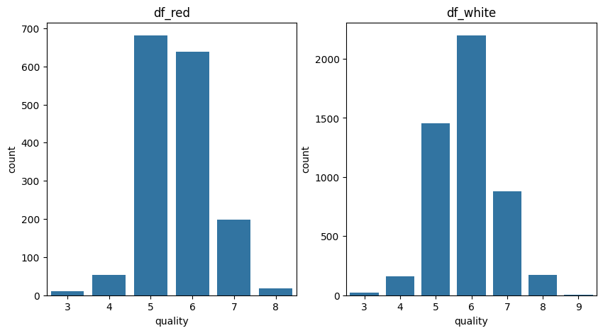

```python
target_bar_compare(df_red, df_white)
```

### Silhouette and inertia plots

Here we plot inertia and silhouette scores for different numbers of clusters to help determine the optimal number of clusters with the elbow method.  
The results suggest that 2 or 3 clusters may be optimal for both datasets, as indicated by the elbow in the inertia plot and the peak in the silhouette score plot.

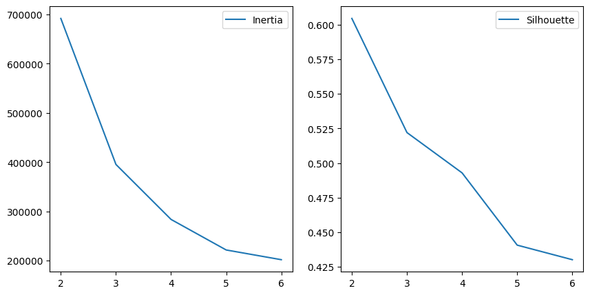

```python
inertia_silouette_score_plot(red_unlabeled, size=7)
```

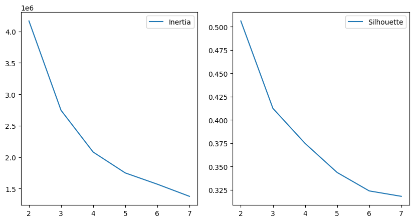

```python
inertia_silouette_score_plot(white_unlabeled, size=8)
```

### Correlation matrices heatmaps

The correlation matrices for the red and white wine datasets reveal notable differences in feature interrelationships, which can influence how clusters are formed.

- In the red wine dataset, there is a strong positive correlation between fixed acidity and citric acid as well as between density and fixed acidity. Additionally, pH shows a strong negative correlation with fixed acidity, indicating that acidity features are closely linked.
- In the white wine dataset, density exhibits a very strong positive correlation with residual sugar and a strong negative correlation with alcohol, patterns that are less pronounced in the red wine data.

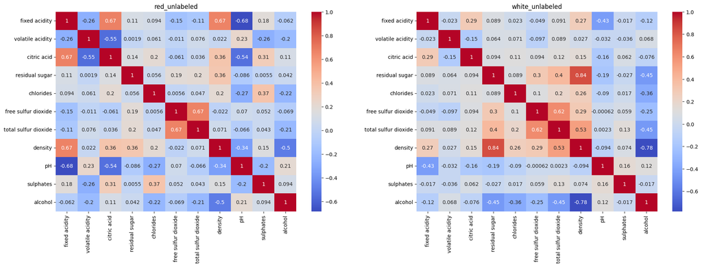

```python
corr_matrix_compare(red_unlabeled, white_unlabeled)
```

What to look for

Average silhouette (dashed line)

Higher is better. Rough guide: >0.5 good, 0.25–0.5 fair, <0.25 poor.

Prefer a peak or clear local maximum; if it keeps rising while clusters become tiny, you’re over-splitting.

Cluster shapes (filled wedges)

Mostly positive values, few or no bars dipping below 0 → good separation.

Tall, fat wedges with small negative tails are healthy; long negative tails mean many points lie on boundaries/misassigned.

Cluster sizes (wedge widths)

Very skinny wedges = tiny clusters/singletons → likely over-clustering.

Extreme size imbalance can be fine, but if the small ones have low silhouettes, that k is suspect.

Consistency across clusters

You want most clusters to sit near or above the dashed line. If only one cluster is great and the rest are mediocre/negative, that k is weak.

### Coefficient plots

(This checklist is generated from [GPT](https://chatgpt.com/share/68f03b67-5300-800e-b4fa-75966c685a0e).)  
Here we're looking for the following patterns:

- Average silhouette (dashed line) Higher is better. Rough guide: >0.5 good, 0.25–0.5 fair, <0.25 poor.
- Cluster shapes (filled wedges) Mostly positive values, few or no bars dipping below 0 → good separation.  
  Tall, fat wedges with small negative tails are healthy; long negative tails mean many points lie on boundaries/misassigned.
- Cluster sizes (wedge widths) Very skinny wedges = tiny clusters/singletons → likely over-clustering.  
  Extreme size imbalance can be fine, but if the small ones have low silhouettes, that k is suspect.
- Consistency across clusters You want most clusters to sit near or above the dashed line. If only one cluster is great and the rest are mediocre/negative, that k is weak.
- How to decide
  - Pick the smallest k that gives a high average silhouette, few negatives, and no tiny sliver clusters.
  - Verify with a second index (e.g., Calinski–Harabasz up, Davies–Bouldin down) and stability (repeat fits, check ARI between runs).
  - Always standardize features before k-means, and evaluate on a hold-out (fit on train, score on val) if you’re tuning k.

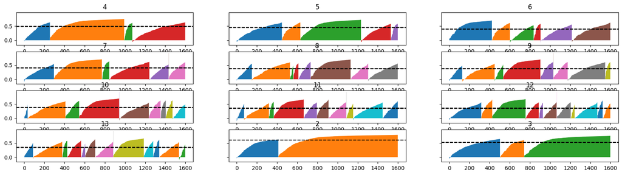

```python
silhouette_coefficient_plot(red_unlabeled, levels=4, width=3, size=14)
```

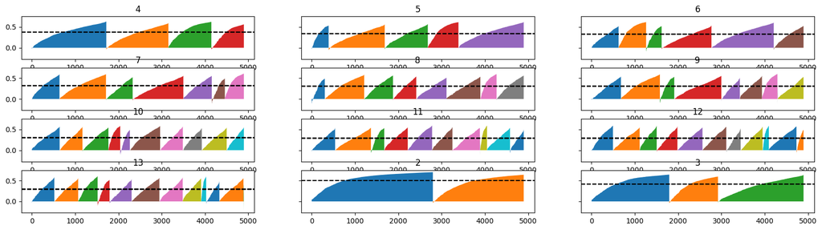

```python
silhouette_coefficient_plot(white_unlabeled, levels=4, width=3, size=14)
```

The results of coefficient plots suggest that for both red and white wine datasets, 2 or 3 clusters may be optimal.

### Manual KMeans parameter tuning

To simplify the analysis, I've created a function that runs KMeans clustering for different numbers of clusters (k) and random seeds, and evaluates the results using internal and external metrics. This allows us to systematically explore how different configurations affect clustering performance.

```python
run_kmeans(red_unlabeled, red_target)
```

|  | algo | k | seed | silhouette | dbi | ari | homo | comp | v |
| --- | --- | --- | --- | --- | --- | --- | --- | --- | --- |
| 0 | kmeans | 2 | 0 | 0.213942 | 1.870302 | 0.043716 | 0.029018 | 0.052264 | 0.037317 |
| 1 | kmeans | 2 | 1 | 0.213942 | 1.870302 | 0.043716 | 0.029018 | 0.052264 | 0.037317 |
| 2 | kmeans | 2 | 2 | 0.213730 | 1.871100 | 0.043276 | 0.028835 | 0.051881 | 0.037068 |
| 3 | kmeans | 2 | 3 | 0.213730 | 1.871100 | 0.043276 | 0.028835 | 0.051881 | 0.037068 |
| 4 | kmeans | 2 | 4 | 0.213730 | 1.871100 | 0.043276 | 0.028835 | 0.051881 | 0.037068 |
| 5 | kmeans | 2 | 5 | 0.213730 | 1.871100 | 0.043276 | 0.028835 | 0.051881 | 0.037068 |
| 6 | kmeans | 2 | 6 | 0.213730 | 1.871100 | 0.043276 | 0.028835 | 0.051881 | 0.037068 |
| 7 | kmeans | 2 | 7 | 0.213730 | 1.871100 | 0.043276 | 0.028835 | 0.051881 | 0.037068 |
| 8 | kmeans | 2 | 8 | 0.213942 | 1.870302 | 0.043716 | 0.029018 | 0.052264 | 0.037317 |
| 9 | kmeans | 2 | 9 | 0.213730 | 1.871100 | 0.043276 | 0.028835 | 0.051881 | 0.037068 |
| 10 | kmeans | 3 | 0 | 0.189245 | 1.766463 | 0.029441 | 0.052380 | 0.058405 | 0.055228 |
| 11 | kmeans | 3 | 1 | 0.189204 | 1.767265 | 0.029208 | 0.052192 | 0.058172 | 0.055020 |
| 12 | kmeans | 3 | 2 | 0.189386 | 1.766350 | 0.029450 | 0.052354 | 0.058388 | 0.055206 |
| 13 | kmeans | 3 | 3 | 0.189245 | 1.766463 | 0.029441 | 0.052380 | 0.058405 | 0.055228 |
| 14 | kmeans | 3 | 4 | 0.189245 | 1.766463 | 0.029441 | 0.052380 | 0.058405 | 0.055228 |
| 15 | kmeans | 3 | 5 | 0.189204 | 1.767265 | 0.029208 | 0.052192 | 0.058172 | 0.055020 |
| 16 | kmeans | 3 | 6 | 0.189204 | 1.767265 | 0.029208 | 0.052192 | 0.058172 | 0.055020 |
| 17 | kmeans | 3 | 7 | 0.189386 | 1.766350 | 0.029450 | 0.052354 | 0.058388 | 0.055206 |
| 18 | kmeans | 3 | 8 | 0.189204 | 1.767265 | 0.029208 | 0.052192 | 0.058172 | 0.055020 |
| 19 | kmeans | 3 | 9 | 0.189245 | 1.766463 | 0.029441 | 0.052380 | 0.058405 | 0.055228 |
| 20 | kmeans | 4 | 0 | 0.205378 | 1.505312 | 0.032234 | 0.057088 | 0.059805 | 0.058415 |
| 21 | kmeans | 4 | 1 | 0.205378 | 1.505312 | 0.032234 | 0.057088 | 0.059805 | 0.058415 |
| 22 | kmeans | 4 | 2 | 0.205378 | 1.505312 | 0.032234 | 0.057088 | 0.059805 | 0.058415 |
| 23 | kmeans | 4 | 3 | 0.205378 | 1.505312 | 0.032234 | 0.057088 | 0.059805 | 0.058415 |
| 24 | kmeans | 4 | 4 | 0.206439 | 1.502587 | 0.033522 | 0.057336 | 0.060037 | 0.058655 |
| 25 | kmeans | 4 | 5 | 0.205304 | 1.508020 | 0.031895 | 0.057064 | 0.059694 | 0.058350 |
| 26 | kmeans | 4 | 6 | 0.206305 | 1.502906 | 0.033717 | 0.057547 | 0.060237 | 0.058861 |
| 27 | kmeans | 4 | 7 | 0.205378 | 1.505312 | 0.032234 | 0.057088 | 0.059805 | 0.058415 |
| 28 | kmeans | 4 | 8 | 0.171835 | 1.655595 | 0.063465 | 0.099567 | 0.086744 | 0.092714 |
| 29 | kmeans | 4 | 9 | 0.205933 | 1.503525 | 0.033882 | 0.057821 | 0.060446 | 0.059104 |
| 30 | kmeans | 5 | 0 | 0.190270 | 1.461351 | 0.064645 | 0.104515 | 0.086958 | 0.094931 |
| 31 | kmeans | 5 | 1 | 0.190359 | 1.461809 | 0.064405 | 0.102548 | 0.085324 | 0.093147 |
| 32 | kmeans | 5 | 2 | 0.190270 | 1.461351 | 0.064645 | 0.104515 | 0.086958 | 0.094931 |
| 33 | kmeans | 5 | 3 | 0.190409 | 1.461389 | 0.064955 | 0.104873 | 0.087253 | 0.095255 |
| 34 | kmeans | 5 | 4 | 0.190270 | 1.461351 | 0.064645 | 0.104515 | 0.086958 | 0.094931 |
| 35 | kmeans | 5 | 5 | 0.190270 | 1.461351 | 0.064645 | 0.104515 | 0.086958 | 0.094931 |
| 36 | kmeans | 5 | 6 | 0.190270 | 1.461351 | 0.064645 | 0.104515 | 0.086958 | 0.094931 |
| 37 | kmeans | 5 | 7 | 0.190456 | 1.468318 | 0.064539 | 0.105048 | 0.087229 | 0.095313 |
| 38 | kmeans | 5 | 8 | 0.190226 | 1.460978 | 0.065157 | 0.105007 | 0.087364 | 0.095376 |
| 39 | kmeans | 5 | 9 | 0.190270 | 1.461351 | 0.064645 | 0.104515 | 0.086958 | 0.094931 |
| 40 | kmeans | 6 | 0 | 0.194327 | 1.398742 | 0.062733 | 0.103440 | 0.081587 | 0.091223 |
| 41 | kmeans | 6 | 1 | 0.194645 | 1.395514 | 0.062080 | 0.102696 | 0.081159 | 0.090666 |
| 42 | kmeans | 6 | 2 | 0.194196 | 1.395999 | 0.062007 | 0.102406 | 0.080845 | 0.090357 |
| 43 | kmeans | 6 | 3 | 0.180162 | 1.470919 | 0.076615 | 0.122558 | 0.089788 | 0.103644 |
| 44 | kmeans | 6 | 4 | 0.194252 | 1.396084 | 0.062567 | 0.102988 | 0.081316 | 0.090878 |
| 45 | kmeans | 6 | 5 | 0.194476 | 1.395964 | 0.062930 | 0.101579 | 0.080235 | 0.089654 |
| 46 | kmeans | 6 | 6 | 0.194476 | 1.395964 | 0.062930 | 0.101579 | 0.080235 | 0.089654 |
| 47 | kmeans | 6 | 7 | 0.194729 | 1.398426 | 0.061945 | 0.104954 | 0.082762 | 0.092546 |
| 48 | kmeans | 6 | 8 | 0.194557 | 1.399241 | 0.063195 | 0.102791 | 0.081110 | 0.090673 |
| 49 | kmeans | 6 | 9 | 0.194252 | 1.396084 | 0.062567 | 0.102988 | 0.081316 | 0.090878 |

### KMeans Red tuning evaluation results

After running KMeans clustering on the red wine dataset with various configurations, we observe the following:

- The best internal silhouette score of 0.21 was achieved with k=2 clusters.
- The highest external Adjusted Rand Index (ARI) of 0.076 was obtained with k=6 clusters. Indicating that while the internal cohesion of clusters is best at k=2, the alignment with true labels improves with more clusters.

```python
run_kmeans(white_unlabeled, white_target)
```

|  | algo | k | seed | silhouette | dbi | ari | homo | comp | v |
| --- | --- | --- | --- | --- | --- | --- | --- | --- | --- |
| 0 | kmeans | 2 | 0 | 0.214477 | 1.774592 | 0.025532 | 0.036202 | 0.069432 | 0.047590 |
| 1 | kmeans | 2 | 1 | 0.214477 | 1.774592 | 0.025532 | 0.036202 | 0.069432 | 0.047590 |
| 2 | kmeans | 2 | 2 | 0.214477 | 1.774592 | 0.025532 | 0.036202 | 0.069432 | 0.047590 |
| 3 | kmeans | 2 | 3 | 0.214477 | 1.774592 | 0.025532 | 0.036202 | 0.069432 | 0.047590 |
| 4 | kmeans | 2 | 4 | 0.214477 | 1.774592 | 0.025532 | 0.036202 | 0.069432 | 0.047590 |
| 5 | kmeans | 2 | 5 | 0.214477 | 1.774592 | 0.025532 | 0.036202 | 0.069432 | 0.047590 |
| 6 | kmeans | 2 | 6 | 0.214477 | 1.774592 | 0.025532 | 0.036202 | 0.069432 | 0.047590 |
| 7 | kmeans | 2 | 7 | 0.214477 | 1.774592 | 0.025532 | 0.036202 | 0.069432 | 0.047590 |
| 8 | kmeans | 2 | 8 | 0.214428 | 1.774708 | 0.025481 | 0.036196 | 0.069413 | 0.047581 |
| 9 | kmeans | 2 | 9 | 0.214477 | 1.774592 | 0.025532 | 0.036202 | 0.069432 | 0.047590 |
| 10 | kmeans | 3 | 0 | 0.144680 | 2.101913 | 0.033988 | 0.038242 | 0.045064 | 0.041374 |
| 11 | kmeans | 3 | 1 | 0.144706 | 2.103785 | 0.034148 | 0.038614 | 0.045498 | 0.041774 |
| 12 | kmeans | 3 | 2 | 0.144663 | 2.102140 | 0.034163 | 0.038538 | 0.045410 | 0.041693 |
| 13 | kmeans | 3 | 3 | 0.144706 | 2.103785 | 0.034148 | 0.038614 | 0.045498 | 0.041774 |
| 14 | kmeans | 3 | 4 | 0.144748 | 2.103453 | 0.033919 | 0.038354 | 0.045195 | 0.041494 |
| 15 | kmeans | 3 | 5 | 0.144663 | 2.102140 | 0.034163 | 0.038538 | 0.045410 | 0.041693 |
| 16 | kmeans | 3 | 6 | 0.144704 | 2.102815 | 0.034022 | 0.038316 | 0.045150 | 0.041453 |
| 17 | kmeans | 3 | 7 | 0.144311 | 2.096082 | 0.033921 | 0.037967 | 0.044746 | 0.041079 |
| 18 | kmeans | 3 | 8 | 0.144663 | 2.102140 | 0.034163 | 0.038538 | 0.045410 | 0.041693 |
| 19 | kmeans | 3 | 9 | 0.144663 | 2.102140 | 0.034163 | 0.038538 | 0.045410 | 0.041693 |
| 20 | kmeans | 4 | 0 | 0.158984 | 1.808573 | 0.028645 | 0.037921 | 0.041547 | 0.039651 |
| 21 | kmeans | 4 | 1 | 0.158984 | 1.808573 | 0.028645 | 0.037921 | 0.041547 | 0.039651 |
| 22 | kmeans | 4 | 2 | 0.159003 | 1.808901 | 0.028670 | 0.037974 | 0.041602 | 0.039705 |
| 23 | kmeans | 4 | 3 | 0.158925 | 1.808684 | 0.028902 | 0.038275 | 0.041936 | 0.040022 |
| 24 | kmeans | 4 | 4 | 0.159003 | 1.808901 | 0.028670 | 0.037974 | 0.041602 | 0.039705 |
| 25 | kmeans | 4 | 5 | 0.159003 | 1.808901 | 0.028670 | 0.037974 | 0.041602 | 0.039705 |
| 26 | kmeans | 4 | 6 | 0.158984 | 1.808573 | 0.028645 | 0.037921 | 0.041547 | 0.039651 |
| 27 | kmeans | 4 | 7 | 0.158984 | 1.808573 | 0.028645 | 0.037921 | 0.041547 | 0.039651 |
| 28 | kmeans | 4 | 8 | 0.159003 | 1.808901 | 0.028670 | 0.037974 | 0.041602 | 0.039705 |
| 29 | kmeans | 4 | 9 | 0.159003 | 1.808901 | 0.028670 | 0.037974 | 0.041602 | 0.039705 |
| 30 | kmeans | 5 | 0 | 0.143931 | 1.767596 | 0.037897 | 0.054984 | 0.048957 | 0.051796 |
| 31 | kmeans | 5 | 1 | 0.143972 | 1.767514 | 0.037877 | 0.055039 | 0.049008 | 0.051849 |
| 32 | kmeans | 5 | 2 | 0.143953 | 1.767535 | 0.037881 | 0.055034 | 0.049005 | 0.051845 |
| 33 | kmeans | 5 | 3 | 0.143933 | 1.767559 | 0.037823 | 0.054881 | 0.048868 | 0.051700 |
| 34 | kmeans | 5 | 4 | 0.143973 | 1.767477 | 0.037803 | 0.054936 | 0.048919 | 0.051753 |
| 35 | kmeans | 5 | 5 | 0.143967 | 1.767355 | 0.037968 | 0.055116 | 0.049082 | 0.051924 |
| 36 | kmeans | 5 | 6 | 0.143979 | 1.767180 | 0.037731 | 0.054743 | 0.048743 | 0.051569 |
| 37 | kmeans | 5 | 7 | 0.143795 | 1.765704 | 0.038234 | 0.055133 | 0.049112 | 0.051949 |
| 38 | kmeans | 5 | 8 | 0.143788 | 1.765877 | 0.038212 | 0.055120 | 0.049099 | 0.051935 |
| 39 | kmeans | 5 | 9 | 0.143931 | 1.767596 | 0.037897 | 0.054984 | 0.048957 | 0.051796 |
| 40 | kmeans | 6 | 0 | 0.146127 | 1.690986 | 0.044140 | 0.082941 | 0.065350 | 0.073102 |
| 41 | kmeans | 6 | 1 | 0.145883 | 1.693363 | 0.044595 | 0.083869 | 0.066071 | 0.073914 |
| 42 | kmeans | 6 | 2 | 0.145750 | 1.695434 | 0.045144 | 0.083803 | 0.066141 | 0.073932 |
| 43 | kmeans | 6 | 3 | 0.145889 | 1.696780 | 0.045445 | 0.083712 | 0.066043 | 0.073835 |
| 44 | kmeans | 6 | 4 | 0.145688 | 1.695745 | 0.045435 | 0.084489 | 0.066634 | 0.074507 |
| 45 | kmeans | 6 | 5 | 0.145323 | 1.700341 | 0.045093 | 0.083435 | 0.065759 | 0.073550 |
| 46 | kmeans | 6 | 6 | 0.147481 | 1.685059 | 0.045635 | 0.084267 | 0.066767 | 0.074503 |
| 47 | kmeans | 6 | 7 | 0.145675 | 1.696517 | 0.045294 | 0.083401 | 0.065798 | 0.073561 |
| 48 | kmeans | 6 | 8 | 0.145576 | 1.696696 | 0.045318 | 0.084223 | 0.066423 | 0.074271 |
| 49 | kmeans | 6 | 9 | 0.145819 | 1.692880 | 0.044883 | 0.084054 | 0.066219 | 0.074078 |

### KMeans White tuning evaluation results

After running KMeans clustering on the white wine dataset with various configurations, we observe the following:

- The best internal silhouette score of 0.21 was achieved with k=2 clusters.
- The highest external Adjusted Rand Index (ARI) of 0.045 was obtained with k=6 clusters. Indicating that while the internal cohesion of clusters is best at k=2, the alignment with true labels improves with more clusters.

### Manual Agglomerative parameter tuning

Similar to KMeans, I've created a function that runs Agglomerative Clustering for different numbers of clusters (k) and linkage methods, and evaluates the results using internal and external metrics.

```python
run_agglomerative(red_unlabeled, red_target)
```

|  | algo | k | silhouette | dbi | ari | homo | comp | v |
| --- | --- | --- | --- | --- | --- | --- | --- | --- |
| 0 | agg_ward | 2 | 0.183402 | 2.029574 | 0.088863 | 0.058132 | 0.112222 | 0.076589 |
| 1 | agg_ward | 3 | 0.157747 | 1.973112 | 0.044352 | 0.063855 | 0.069353 | 0.066490 |
| 2 | agg_ward | 4 | 0.171418 | 1.664853 | 0.047928 | 0.071214 | 0.072346 | 0.071775 |
| 3 | agg_ward | 5 | 0.154476 | 1.563835 | 0.056075 | 0.085448 | 0.075691 | 0.080274 |
| 4 | agg_ward | 6 | 0.149503 | 1.526313 | 0.061020 | 0.088377 | 0.069609 | 0.077878 |
| 5 | agg_average | 2 | 0.583376 | 0.923030 | 0.001605 | 0.000538 | 0.016788 | 0.001043 |
| 6 | agg_average | 3 | 0.563167 | 0.640488 | 0.001619 | 0.003180 | 0.091654 | 0.006146 |
| 7 | agg_average | 4 | 0.534095 | 0.697659 | -0.001907 | 0.005493 | 0.057257 | 0.010024 |
| 8 | agg_average | 5 | 0.514467 | 0.600978 | -0.001928 | 0.005758 | 0.056759 | 0.010455 |
| 9 | agg_average | 6 | 0.509435 | 0.542737 | -0.001913 | 0.007797 | 0.075344 | 0.014131 |
| 10 | agg_complete | 2 | 0.682483 | 0.452064 | 0.000994 | 0.001522 | 0.187619 | 0.003020 |
| 11 | agg_complete | 3 | 0.355664 | 1.116405 | -0.001371 | 0.003479 | 0.026940 | 0.006162 |
| 12 | agg_complete | 4 | 0.172353 | 1.836656 | -0.016588 | 0.008768 | 0.014472 | 0.010920 |
| 13 | agg_complete | 5 | 0.173460 | 1.644323 | -0.016653 | 0.009278 | 0.015098 | 0.011493 |
| 14 | agg_complete | 6 | 0.166807 | 1.577820 | -0.019054 | 0.010811 | 0.016035 | 0.012914 |

### Agglomerative Red tuning evaluation results

```python
run_agglomerative(white_unlabeled, white_target)
```

|  | algo | k | silhouette | dbi | ari | homo | comp | v |
| --- | --- | --- | --- | --- | --- | --- | --- | --- |
| 0 | agg_ward | 2 | 0.178399 | 1.995895 | 0.006518 | 0.017929 | 0.034354 | 0.023562 |
| 1 | agg_ward | 3 | 0.182758 | 1.594756 | 0.003184 | 0.019084 | 0.033201 | 0.024237 |
| 2 | agg_ward | 4 | 0.109838 | 2.084981 | 0.014087 | 0.020620 | 0.023522 | 0.021976 |
| 3 | agg_ward | 5 | 0.099907 | 2.067553 | 0.034520 | 0.044269 | 0.040883 | 0.042509 |
| 4 | agg_ward | 6 | 0.071296 | 2.338400 | 0.025547 | 0.054543 | 0.042301 | 0.047648 |
| 5 | agg_average | 2 | 0.786720 | 0.151101 | -0.000150 | 0.000127 | 0.084390 | 0.000253 |
| 6 | agg_average | 3 | 0.738400 | 0.174608 | 0.000237 | 0.001001 | 0.333147 | 0.001996 |
| 7 | agg_average | 4 | 0.691046 | 0.194096 | 0.000270 | 0.001193 | 0.264653 | 0.002375 |
| 8 | agg_average | 5 | 0.574136 | 0.366374 | -0.000030 | 0.001446 | 0.198342 | 0.002872 |
| 9 | agg_average | 6 | 0.522093 | 0.363226 | -0.000180 | 0.001573 | 0.178885 | 0.003119 |
| 10 | agg_complete | 2 | 0.786720 | 0.151101 | -0.000150 | 0.000127 | 0.084390 | 0.000253 |
| 11 | agg_complete | 3 | 0.738400 | 0.174608 | 0.000237 | 0.001001 | 0.333147 | 0.001996 |
| 12 | agg_complete | 4 | 0.457049 | 0.556913 | -0.002600 | 0.002901 | 0.049725 | 0.005483 |
| 13 | agg_complete | 5 | 0.444806 | 0.626783 | -0.003314 | 0.003302 | 0.050297 | 0.006197 |
| 14 | agg_complete | 6 | 0.170343 | 1.026220 | 0.007984 | 0.027458 | 0.049457 | 0.035311 |

### Agglomerative White tuning evaluation results

After running Agglomerative Clustering on the white wine dataset with various configurations, we observe the following:

- The best internal silhouette score of 0.78 was achieved with k=2 clusters and either the 'complete' or 'average' linkage method.
- The highest external Adjusted Rand Index (ARI) of 0.034 was obtained with k=5 clusters and the 'ward' linkage method, indicating that this configuration provides the best alignment with true labels, but has an overall weak internal cohesion.

### Model evaluation summary

When taking the ARI external metric as the primary criterion, the optimal configurations are:

- Red wine: Agglomerative Clustering with k=2 and 'ward' linkage (ARI=0.088)
- White wine: KMeans with k=6 (ARI=0.045)

### Scatter plots of PCA(2) Internal evaluation

To visualize the clustering results, we reduce the data to 2 dimensions using PCA and create scatter plots colored by cluster labels.  
I've based the plots on the best silhouette score identified above.

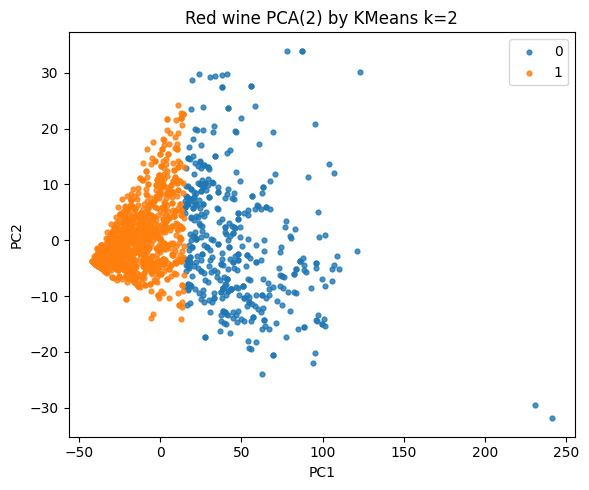

```python
kmeans_red_internal = KMeans(n_clusters=2, n_init=20).fit_predict(red_unlabeled)

pca_scatter(red_unlabeled, kmeans_red_internal, title="Red wine PCA(2) by KMeans k=2")
```

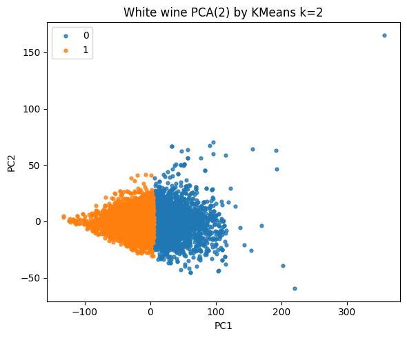

```python
kmeans_white_internal = KMeans(n_clusters=2, n_init=20).fit_predict(white_unlabeled)
pca_scatter(white_unlabeled, kmeans_white_internal, title="White wine PCA(2) by KMeans k=2")
```

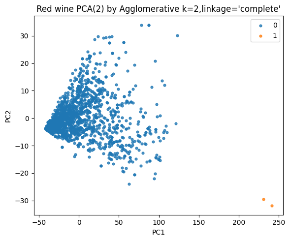

```python
agg_red_internal = AgglomerativeClustering(n_clusters=2, linkage='complete').fit_predict(red_unlabeled)
pca_scatter(red_unlabeled, agg_red_internal, title="Red wine PCA(2) by Agglomerative k=2,linkage='complete'")
```

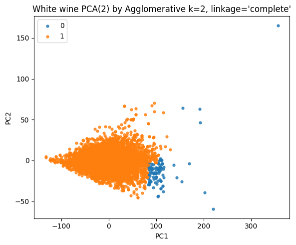

```python
agg_white_internal = AgglomerativeClustering(n_clusters=2, linkage='complete').fit_predict(white_unlabeled)
pca_scatter(white_unlabeled, agg_white_internal, title="White wine PCA(2) by Agglomerative k=2, linkage='complete'")
```

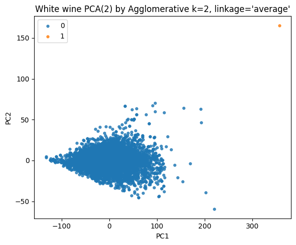

```python
agg_white_internal = AgglomerativeClustering(n_clusters=2, linkage='average').fit_predict(white_unlabeled)
pca_scatter(white_unlabeled, agg_white_internal, title="White wine PCA(2) by Agglomerative k=2, linkage='average'")
```